# CP1 - P4

9 de setembro de 2016

# Os Dados

Os dados aqui analisados são referentes a filmes e seus respectivos gêneros, avaliações, títulos, etc. Esses dados podem ser encontrados em: http://grouplens.org/datasets/movielens/latest/. Para essa análise usaremos o dataset small.

# 1 - Escolha uma trilogia (ou uma n-logia com n > 3) e avalie para qual dos episódios da trilogia há melhor avaliação e para qual há mais variação nas notas atribuídas ao filme.

Para responder essa questão foi escolhido os dados referentes aos 8 Filmes de Harry Potter. Para responder a parte da melhor avaliação primeiramente nós testamos a média de avalições de cada filme. E o resultado foi:

# Média

Utilizando um intervalo de confiança de 2,5% até 97,5% nós podemos dizer que a média de avaliações do respectivo filme está dentro daquele intervalo. Infelizmente se observamos os intervalos vemos que todos estão se interceptando, portanto não é possível afirmar qual o que tem a melhor avaliação em média.

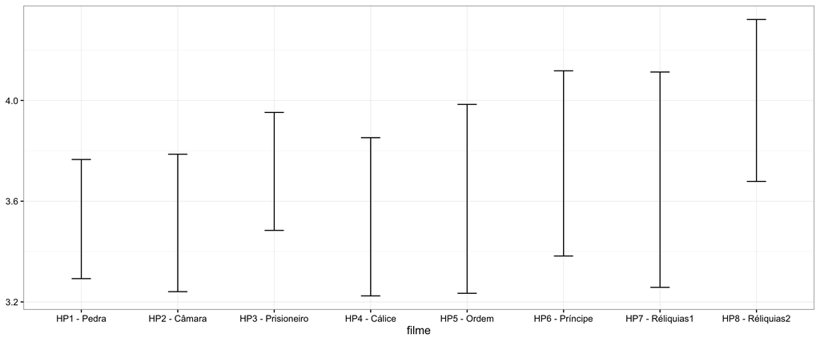

```r
b = bootstrap(hp1Ratings, mean(rating), R = reps)
hp1Ratings.ci = CI.bca(b, probs = ci)
row.names(hp1Ratings.ci) <- "HP1 - Pedra"

b = bootstrap(hp2Ratings, mean(rating), R = reps)
hp2Ratings.ci = CI.bca(b, probs = ci)
row.names(hp2Ratings.ci) <- "HP2 - Câmara"

b = bootstrap(hp3Ratings, mean(rating), R = reps)
hp3Ratings.ci = CI.bca(b, probs = ci)
row.names(hp3Ratings.ci) <- "HP3 - Prisioneiro"

b = bootstrap(hp4Ratings, mean(rating), R = reps)
hp4Ratings.ci = CI.bca(b, probs = ci)
row.names(hp4Ratings.ci) <- "HP4 - Cálice"

b = bootstrap(hp5Ratings, mean(rating), R = reps)
hp5Ratings.ci = CI.bca(b, probs = ci)
row.names(hp5Ratings.ci) <- "HP5 - Ordem"

b = bootstrap(hp6Ratings, mean(rating), R = reps)
hp6Ratings.ci = CI.bca(b, probs = ci)
row.names(hp6Ratings.ci) <- "HP6 - Príncipe"

b = bootstrap(hp7Ratings, mean(rating), R = reps)
hp7Ratings.ci = CI.bca(b, probs = ci)
row.names(hp7Ratings.ci) <- "HP7 - Réliquias1"

b = bootstrap(hp8Ratings, mean(rating), R = reps)
hp8Ratings.ci = CI.bca(b, probs = ci)
row.names(hp8Ratings.ci) <- "HP8 - Réliquias2"

df = data.frame(rbind(hp1Ratings.ci,
                      hp2Ratings.ci,
                      hp3Ratings.ci,
                      hp4Ratings.ci,
                      hp5Ratings.ci,
                      hp6Ratings.ci,
                      hp7Ratings.ci,
                      hp8Ratings.ci))

df$filme = row.names(df)

df %>%
  ggplot(aes(x = filme, ymin = X2.5., ymax = X97.5.)) +
  geom_errorbar(width = .2)
```

# Mediana

Para tentar contorna o problema das intersecções tentou-se aumentar o número de repetições e diminuir a confiança, porém mesmo assim os intervalos ainda apresentavam muitas intersecções. Como o resultado para a média foi inconclusivo decidiu-se então utilizar a mediana como medida parâmetro, ainda utilizando a mesma confiança da média.

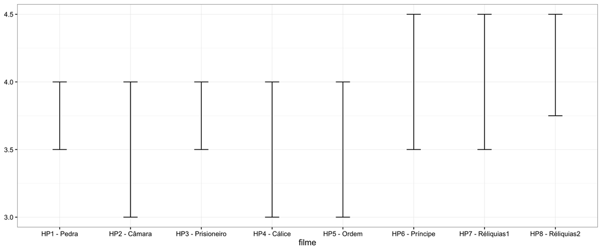

```r
b = bootstrap(hp1Ratings, median(rating), R = reps)
hp1Ratings.ci = CI.percentile(b, probs = ci)
row.names(hp1Ratings.ci) <- "HP1 - Pedra"

b = bootstrap(hp2Ratings, median(rating), R = reps)
hp2Ratings.ci = CI.percentile(b, probs = ci)
row.names(hp2Ratings.ci) <- "HP2 - Câmara"

b = bootstrap(hp3Ratings, median(rating), R = reps)
hp3Ratings.ci = CI.percentile(b, probs = ci)
row.names(hp3Ratings.ci) <- "HP3 - Prisioneiro"

b = bootstrap(hp4Ratings, median(rating), R = reps)
hp4Ratings.ci = CI.percentile(b, probs = ci)
row.names(hp4Ratings.ci) <- "HP4 - Cálice"

b = bootstrap(hp5Ratings, median(rating), R = reps)
hp5Ratings.ci = CI.percentile(b, probs = ci)
row.names(hp5Ratings.ci) <- "HP5 - Ordem"

b = bootstrap(hp6Ratings, median(rating), R = reps)
hp6Ratings.ci = CI.percentile(b, probs = ci)
row.names(hp6Ratings.ci) <- "HP6 - Príncipe"

b = bootstrap(hp7Ratings, median(rating), R = reps)
hp7Ratings.ci = CI.percentile(b, probs = ci)
row.names(hp7Ratings.ci) <- "HP7 - Réliquias1"

b = bootstrap(hp8Ratings, median(rating), R = reps)
hp8Ratings.ci = CI.percentile(b, probs = ci)
row.names(hp8Ratings.ci) <- "HP8 - Réliquias2"

df = data.frame(rbind(hp1Ratings.ci,
                      hp2Ratings.ci,
                      hp3Ratings.ci,
                      hp4Ratings.ci,
                      hp5Ratings.ci,
                      hp6Ratings.ci,
                      hp7Ratings.ci,
                      hp8Ratings.ci))

df$filme = row.names(df)

df %>%
  ggplot(aes(x = filme, ymin = X2.5., ymax = X97.5.)) +
  geom_errorbar(width = .2)
```

# Variância

Analizando os intervalos para a variância também é impossível dizer qual o filme que tem a maior variação nas avaliações, nesse caso nós podemos considerar que estatisticamente eles tem a mesma variância.

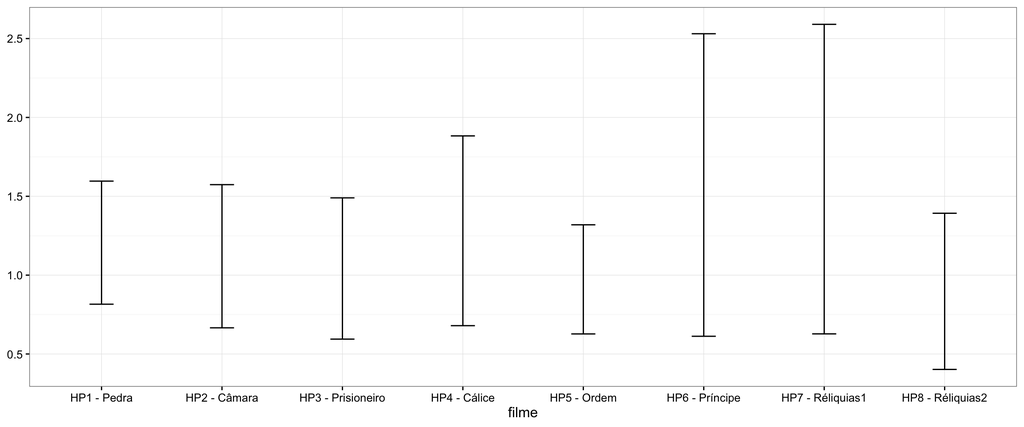

```r
b = bootstrap(hp1Ratings, var(rating), R = reps)
hp1Ratings.ci = CI.bca(b, probs = ci)
row.names(hp1Ratings.ci) <- "HP1 - Pedra"

b = bootstrap(hp2Ratings, var(rating), R = reps)
hp2Ratings.ci = CI.bca(b, probs = ci)
row.names(hp2Ratings.ci) <- "HP2 - Câmara"

b = bootstrap(hp3Ratings, var(rating), R = reps)
hp3Ratings.ci = CI.bca(b, probs = ci)
row.names(hp3Ratings.ci) <- "HP3 - Prisioneiro"

b = bootstrap(hp4Ratings, var(rating), R = reps)
hp4Ratings.ci = CI.bca(b, probs = ci)
row.names(hp4Ratings.ci) <- "HP4 - Cálice"

b = bootstrap(hp5Ratings, var(rating), R = reps)
hp5Ratings.ci = CI.bca(b, probs = ci)
row.names(hp5Ratings.ci) <- "HP5 - Ordem"

b = bootstrap(hp6Ratings, var(rating), R = reps)
hp6Ratings.ci = CI.bca(b, probs = ci)
row.names(hp6Ratings.ci) <- "HP6 - Príncipe"

b = bootstrap(hp7Ratings, var(rating), R = reps)
hp7Ratings.ci = CI.bca(b, probs = ci)
row.names(hp7Ratings.ci) <- "HP7 - Réliquias1"

b = bootstrap(hp8Ratings, var(rating), R = reps)
hp8Ratings.ci = CI.bca(b, probs = ci)
row.names(hp8Ratings.ci) <- "HP8 - Réliquias2"

df = data.frame(rbind(hp1Ratings.ci,
                      hp2Ratings.ci,
                      hp3Ratings.ci,
                      hp4Ratings.ci,
                      hp5Ratings.ci,
                      hp6Ratings.ci,
                      hp7Ratings.ci,
                      hp8Ratings.ci))

df$filme = row.names(df)

df %>%
  ggplot(aes(x = filme, ymin = X2.5., ymax = X97.5.)) +
  geom_errorbar(width = .2)
```

# 2 - Normalmente os filmes têm vários gêneros. Existe uma relação entre em quantos gêneros os filmes se encaixam e a avaliação que os filmes recebem? Mais especificamente: se consideramos a os filmes com 1, 2, 3 … gêneros, existe alguma quantidade de gêneros num mesmo filme que em geral recebe avaliações melhores? Caso exista, estime a diferença entre essa combinação e filmes com apenas um gênero.

Para a nossa análise iremos desconsiderar os grupos que tem menos de 30 avaliações, nesse caso os filmes com mais de 7 gêneros.

# Mediana

Analisando a mediana não conseguimos dizer qual dos grupos que tem a maior avaliação, nós só conseguimos dizer que: Se pegarmos uma pessoa aleatória que acaba de assistir um filme de 7 gêneros, elas tendem a dar uma maior avaliação que as pessoas que assistem filmes de 1, 2 ou 4 gêneros.

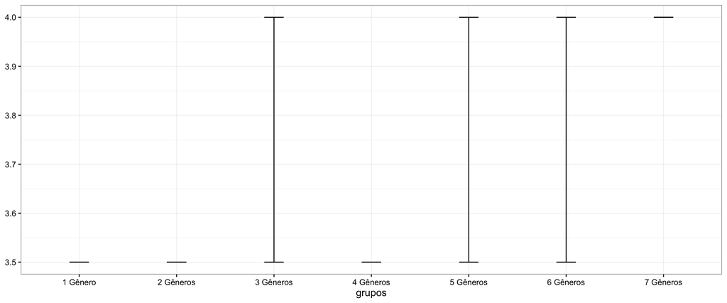

```r
b = bootstrap(g1Ratings, median(rating), R = reps)
g1Ratings.ci = CI.percentile(b, probs = ci)
row.names(g1Ratings.ci) <- "1 Gênero"

b = bootstrap(g2Ratings, median(rating), R = reps)
g2Ratings.ci = CI.percentile(b, probs = ci)
row.names(g2Ratings.ci) <- "2 Gêneros"

b = bootstrap(g3Ratings, median(rating), R = reps)
g3Ratings.ci = CI.percentile(b, probs = ci)
row.names(g3Ratings.ci) <- "3 Gêneros"

b = bootstrap(g4Ratings, median(rating), R = reps)
g4Ratings.ci = CI.percentile(b, probs = ci)
row.names(g4Ratings.ci) <- "4 Gêneros"

b = bootstrap(g5Ratings, median(rating), R = reps)
g5Ratings.ci = CI.percentile(b, probs = ci)
row.names(g5Ratings.ci) <- "5 Gêneros"

b = bootstrap(g6Ratings, median(rating), R = reps)
g6Ratings.ci = CI.percentile(b, probs = ci)
row.names(g6Ratings.ci) <- "6 Gêneros"

b = bootstrap(g7Ratings, median(rating), R = reps)
g7Ratings.ci = CI.percentile(b, probs = ci)
row.names(g7Ratings.ci) <- "7 Gêneros"

df = data.frame(rbind(g1Ratings.ci,
                      g2Ratings.ci,
                      g3Ratings.ci,
                      g4Ratings.ci,
                      g5Ratings.ci,
                      g6Ratings.ci,
                      g7Ratings.ci))

df$grupos = row.names(df)

df %>%
  ggplot(aes(x = grupos, ymin = X2.5., ymax = X97.5.)) +
  geom_errorbar(width = .2)
```

# Diferença

Analisando as médias das diferenças entre as avaliações de filmes com 7 gêneros e filmes de 1 gênero, podemos observar que como o intervalo é positivos, nós podemos dizer que as avaliações de filmes com 7 gêneros são maiores que as de 1 gênero.

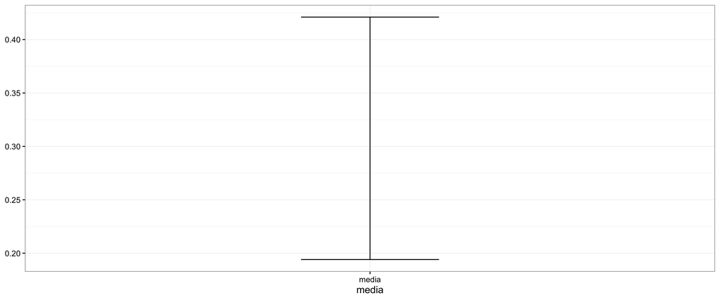

```r
b = bootstrap2(data = g7Ratings$rating,
               data2 = g1Ratings$rating,
               mean)

medians.diff = CI.percentile(b, probs = ci)

df = data.frame(rbind(medians.diff))

df$media = "media"

df %>%
  ggplot(aes(x = media, ymin = X2.5., ymax = X97.5.)) +
  geom_errorbar(width = .2)
```